# R Modelo Red Neuronal para predecir Valores

Tomado de : https://fcharte.com/tutoriales/20160203-R-RedesNeuronales/

Una red neuronal artificial (ANN, Artificial Neural Network), asumiendo que tenga la estructura adecuada y cuente con un algoritmo de aprendizaje correcto, es capaz de aprender a realizar teóricamente cualquier operación, sin necesidad de que le facilitemos su formulación matemática. Solo necesita que le facilitemos varios ejemplos de la salida que se produce a partir de ciertas entradas. Si los ejemplos son suficientes y representativos del problema, tras el aprendizaje la red neuronal será capaz de efectuar dicha operación con una alta precisión.

1. El primer paso es cargar los paquetes, introduciendo en la consola de R el siguiente comando:

```r
library(dplyr)
library(ggplot2)
library(neuralnet)
```

1.1 Datos de ejemplo Lo primero que necesitamos son algunos datos de ejemplo que permitan a la ANN aprender la función. Para ello vamos a preparar un data.frame (un tipo de dato de R similar a una matriz) con 100 filas, un centenar de ejemplos, cada una de las cuales tendrá tres columnas. Las dos primeras contendrán las medidas de dos catetos y las obtendremos así:

```r
set.seed(42)  # Establece la semilla aleatoria para asegurar reproducibilidad

data <- data.frame(
  Cat1 = round(runif(100, min = 1, max = 10)),
  Cat2 = round(runif(100, min = 1, max = 10)))

head(data)
```

|  | Cat1 | Cat2 |
| --- | --- | --- |
| 1 | 9 | 7 |
| 2 | 9 | 3 |
| 3 | 4 | 3 |
| 4 | 8 | 5 |
| 5 | 7 | 9 |
| 6 | 6 | 10 |

```r
NA
NA
```

La función runif() devuelve valores de una distribución uniforme. En este caso concreto le solicitamos 100 valores entre 1 y 10 para cada uno de los catetos. Podemos comprobar cuál es el contenido del data.frame simplemente escribiendo en la consola data y pulsando Intro. Esto mostraría las 100 filas. Para comprobar la estructura es suficiente con algunas de ellas, devueltas por la función head().

El data.frame debe tener una columna adicional con la hipotenusa correspondiente a cada pareja de catetos. La añadimos de la siguiente manera:

```r
data$Hyp <- sqrt(data$Cat1*data$Cat1 + data$Cat2*data$Cat2)

head(data)
```

|  | Cat1 | Cat2 | Hyp |
| --- | --- | --- | --- |
| 1 | 9 | 7 | 11.401754 |
| 2 | 9 | 3 | 9.486833 |
| 3 | 4 | 3 | 5.000000 |
| 4 | 8 | 5 | 9.433981 |
| 5 | 7 | 9 | 11.401754 |
| 6 | 6 | 10 | 11.661904 |

1.2 Particiones de entrenamiento y validación De los 100 ejemplos que contiene nuestro data.frame vamos a usar una parte para que la ANN aprenda (partición de entrenamiento o training) y otra para comprobar lo bien que ha aprendido (partición de validación o test). Lo habitual, cuando no se va a efectuar validación cruzada (varias repeticiones del experimento con distintas particiones de datos), es tomar dos tercios para entrenamiento y el tercio restante para validación. También es habitual seleccionar los ejemplos de forma aleatoria.

Mediante la función sample() vamos a tomar aleatoriamente un tercio de los índices correspondientes a las filas (ejemplos) existentes en el data.frame. El número de filas se obtiene con la función nrow(). Lo que obtenemos como resultado, según puede apreciarse a continuación, es un vector con índices aleatorios, no los datos en sí:

```r
fold.test <- sample(nrow(data), nrow(data) / 3)
fold.test
```

```
 [1] 24 98 25 92 61 62 14 34 66 32 27 10 57 28 37 89  5 35 78 94 87 54
[23] 31 43 52 59 90 30 76 17 95 13 63
```

Esos índices, un tercio del total, serán los correspondientes a los ejemplos que usaremos para validación. Cuando se trabaja con un data.frame es posible acceder a cualquier dato individual mediante la notación variable[nfila, ncolumna]. También es posible obtener múltiples datos simultáneamente, usando como índices vectores de números. Si el número de fila o columna es omitido se asume que se tomarán todas las filas o todas las columnas, según el caso.

Para crear nuestra partición de entrenamiento y de validación usaremos los índices anteriores, almacenados en la variable fold.test, para seleccionar las filas adecuadas del data.frame:

```r
test  <- data[fold.test, ] # total las filas de fold.test
train <- data[-fold.test, ] # total las filas menos las de folt.test

head(test)
```

|  | Cat1 | Cat2 | Hyp |
| --- | --- | --- | --- |
| 24 | 10 | 6 | 11.661904 |
| 98 | 6 | 2 | 6.324555 |
| 25 | 2 | 7 | 7.280110 |
| 92 | 1 | 8 | 8.062258 |
| 61 | 7 | 9 | 11.401754 |
| 62 | 10 | 6 | 11.661904 |

```r
head(train)
```

|  | Cat1 | Cat2 | Hyp |
| --- | --- | --- | --- |
| 1 | 9 | 7 | 11.401754 |
| 2 | 9 | 3 | 9.486833 |
| 3 | 4 | 3 | 5.000000 |
| 4 | 8 | 5 | 9.433981 |
| 6 | 6 | 10 | 11.661904 |
| 7 | 8 | 8 | 11.313708 |

Con la expresión data[fold.test, ] estamos tomando del data.frame original las tres columnas de las filas cuyos índices contiene fold.test. La expresión data[-fold.test, ] es similar, pero tomando las filas cuyos índices no están en el vector fold.test. De esta forma obtenemos dos conjuntos disjuntos de ejemplos, uno en la variable train y otro en la variable test. Ambas son objetos data.frame, con las mismas tres columnas que data.

Entrenamiento de la red neuronal Teniendo preparados los datos que actuarán como ejemplos de la función a aprender, estamos en disposición de entrenar nuestra red neuronal. Para ello no hay más que invocar a la función neuralnet() mencionada anteriormente. Esta puede tomar un conjunto bastante importante de parámetros, algunos de ellos relativamente complejos, pero la mayor parte toman valores por defecto adecuados, por lo que en la práctica bastará con una llamada como la siguiente:

```r
ann <- neuralnet(Hyp ~ Cat1 + Cat2, train, hidden = 10, rep = 3)
```

Los dos primeros parámetros son obligatorios. El primero es una fórmula mediante la que se indica qué variables son predictoras (los catetos) y qué variables se van a predecir (la hipotenusa). La sintaxis es simple: disponemos los nombres de las columnas del data.frame que contienen datos a obtener como resultado de la red neuronal, en este caso es solo una, separados entre sí mediante el operador +. A continuación, tras el símbolo ~, se facilitan las variables de entrada de la misma manera. El segundo parámetro es el data.frame que contiene las variables a las que se hace referencia en la anterior fórmula.

El parámetro hidden es opcional. Con él indicamos el número de neuronas que existirá en cada una de las capas ocultas de la ANN. En este caso vamos a tener una sola capa oculta con 10 neuronas. Por defecto la función neuralnet() efectúa una sola vez el proceso de entrenamiento de la ANN. Con el parámetro rep se cambia el número de repeticiones (en el proceso hay una componente aleatoria que provoca que cada red obtenida tras el entrenamiento sea distinta), con el objetivo de obtener la mejor ANN posible.

El objeto ann tiene varios elementos en su interior, éstos se pueden ver usando el código siguiente:

```r
names(ann)
```

```
 [1] "call"                "response"            "covariate"
 [4] "model.list"          "err.fct"             "act.fct"
 [7] "linear.output"       "data"                "exclude"
[10] "net.result"          "weights"             "generalized.weights"
[13] "startweights"        "result.matrix"
```

```r
ann$response
```

```
          Hyp
1   11.401754
2    9.486833
3    5.000000
4    9.433981
6   11.661904
7   11.313708
8    8.246211
9    9.219544
11   7.810250
12  11.401754
15   7.810250
16  10.816654
18   4.472136
19   8.602325
```

[output cut: 53 more lines]

1.4 Examinando la estructura de la ANN Aunque podemos examinar el contenido de la variable ann para obtener información sobre las conexiones entre las neuronas, incluyendo los pesos asignados a cada una de las conexiones existentes entre ellas, en general nos resultará más sencillo analizar esta información visualmente. Para ello facilitaremos dicha variable a la función plot(), encargada de dibujar la ANN a partir de los datos devueltos por neuralnet(). Dado que en la variable ann tenemos varias ANN, con distintas tasas de error, usaremos el parámetro rep para indicar que se represente la mejor de ellas.

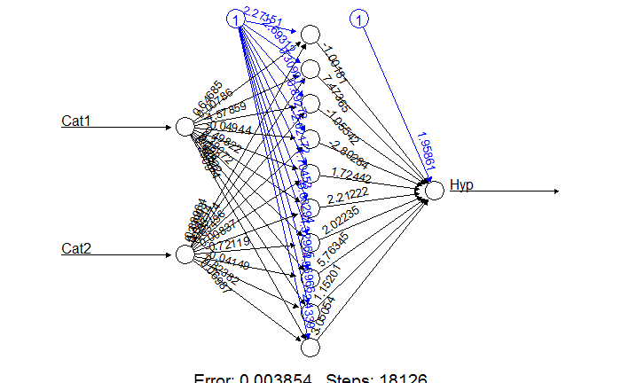

```r
plot(ann, rep = "best")
```

A partir de esta representación, o usando directamente los datos contenidos en la variable ann, podríamos tomar dos valores cualesquiera como catetos y seguir paso a paso su evolución por la ANN. Primero habría que multiplicar esos valores por los pesos que indica cada uno de los enlaces. A continuación sumaríamos todas las entradas que llegan a cada neurona oculta. Sobre ese valor se aplicaría una función, la función de activación de la neurona, que generará un valor de salida. Por defecto neuralnet usa la función de activación logística o sigmoidal. De esta forma se obtiene una salida de cada neurna de la capa oculta. Todas ellas actúan como entrada para la neurona de salida, cuyo valor se calcula como la suma ponderada de todas esas entradas. Esta neurona de salida no efectúa procesamiento alguno sobre dicho valor, como no lo hacen las de entrada.

Además de el diagrama de la red con sus conexiones y pesos, también podemos utilizar la función gwplot() para obtener una representación de los pesos generalizados (GW, Generalized Weights) de una variable de entrada respecto a una de salida. Esto nos permitiría, por ejemplo, determinar qué variable aporta más peso a la predicción de una salida. En nuestra ANN de ejemplo, tras aprender la función hipotenusa, no es de extrañar que ambas variables predictoras tengan una aportación muy similar a la única salida existente, tal y como se aprecia en las siguientes gráficas.

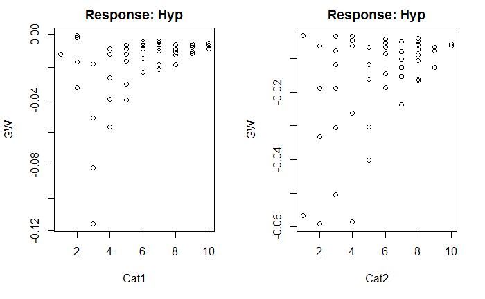

```r
par(mfrow=c(1,2))
gwplot(ann, selected.covariate = 'Cat1', rep = 'best')
gwplot(ann, selected.covariate = 'Cat2', rep = 'best')
```

Usar la red para predecir nuevos resultados Teniendo la red ya entrenada, podemos entregarle nuevas entradas no con el objetivo de que continúe aprendiendo, sino para obtener una predicción de cual debería ser el valor resultante de la función aprendida. Para ello usaremos la función compute(). Para ello le facilitaremos la variable que contiene la configuración de la ANN, un data.frame con los valores para las variables de entrada y, opcionalmente, indicaremos cuál de las repeticiones de la ANN queremos usar.

En el siguiente ejemplo tomamos de la variable test, que contenía datos que nos hemos usado para el entrenamiento de la red, las variables Cat1 y Cat2 y se las facilitamos a la mencionada función. Guardamos el resultado, las predicciones hechas por la ANN, en una variable. A continuación generamos una tabla de resultados mostrando en la primera columna el valor real de la hipotenusa, calculado al inicio con la fórmula estándar, en la segunda el valor predicho por la ANN y en la tercera el error cometido.

```r
output <- compute(ann, test[ , c("Cat1", "Cat2")], rep = 1)
data.frame(Real = test$Hyp, Predicted = output$net.result, Error =  abs(test$Hyp - output$net.result) / test$Hyp)
```

|  | Real | Predicted | Error |
| --- | --- | --- | --- |
| 24 | 11.661904 | 11.687492 | 0.0021941530 |
| 98 | 6.324555 | 6.327011 | 0.0003883067 |
| 25 | 7.280110 | 7.237642 | 0.0058333545 |
| 92 | 8.062258 | 8.063106 | 0.0001052556 |
| 61 | 11.401754 | 11.416441 | 0.0012881254 |
| 62 | 11.661904 | 11.687492 | 0.0021941530 |
| 14 | 5.830952 | 5.837452 | 0.0011147124 |
| 34 | 11.401754 | 11.416441 | 0.0012881254 |
| 66 | 4.242641 | 4.239743 | 0.0006829551 |
| 32 | 10.000000 | 9.994650 | 0.0005349833 |

[output cut: 23 more lines]

```r
NA
```